# Current depressive status

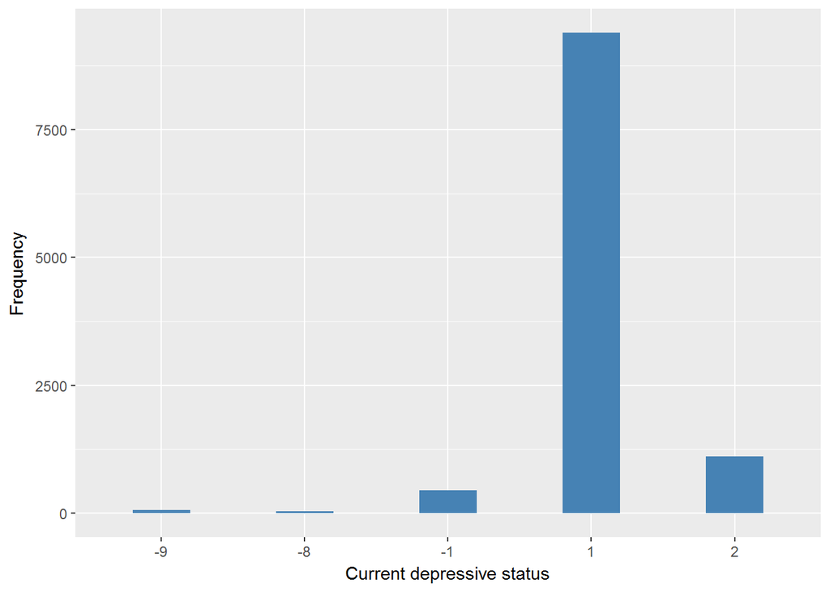

Current depressive status

| Sample size | Missing values |
| --- | --- |
| 11050 | 446 |

Category

|  | -9 | -8 | 1 | 2 |
| --- | --- | --- | --- | --- |
| Frequency | 61.00 | 15.00 | 1340.00 | 9188.00 |
| Percentage | 0.55 | 0.14 | 12.13 | 83.15 |

Type of missing

|  | -17 | -1 | -2 | NA |
| --- | --- | --- | --- | --- |
| Frequency | 0 | 446.00 | 0 | 0 |
| Percentage | 0 | 4.04 | 0 | 0 |

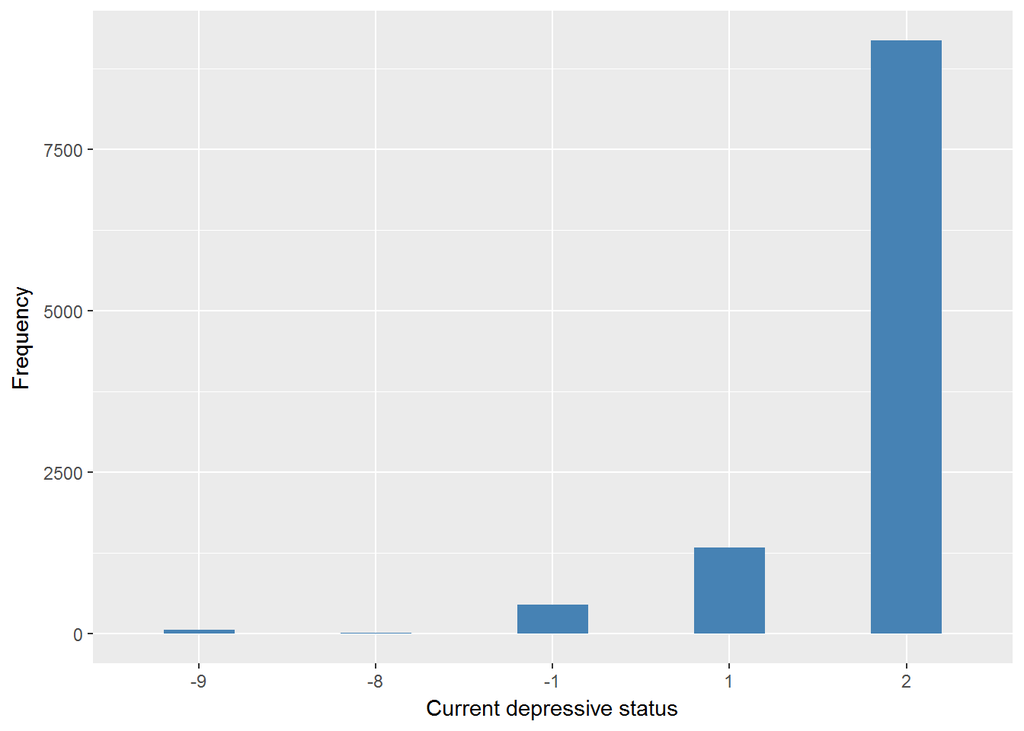

Current depressive status

| Sample size | Missing values |
| --- | --- |
| 11050 | 446 |

Category

|  | -9 | -8 | 1 | 2 |
| --- | --- | --- | --- | --- |
| Frequency | 63.00 | 39.00 | 9478.00 | 1024.00 |
| Percentage | 0.57 | 0.35 | 85.77 | 9.27 |

Type of missing

|  | -17 | -1 | -2 | NA |
| --- | --- | --- | --- | --- |
| Frequency | 0 | 446.00 | 0 | 0 |
| Percentage | 0 | 4.04 | 0 | 0 |

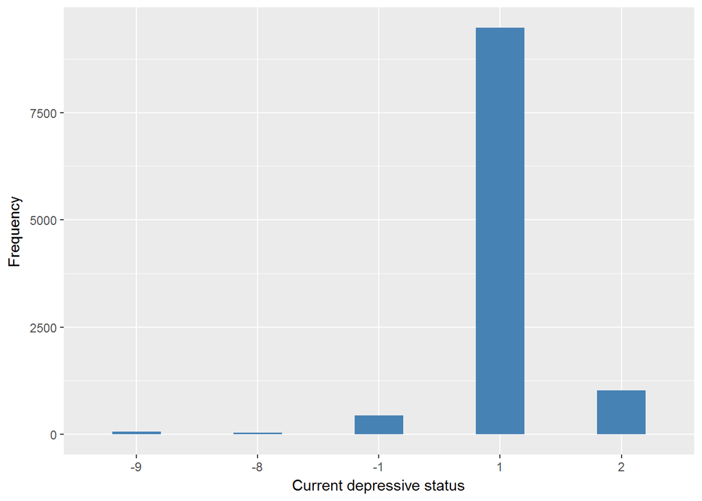

Current depressive status

| Sample size | Missing values |
| --- | --- |
| 11050 | 446 |

Category

|  | -9 | -8 | 1 | 2 |
| --- | --- | --- | --- | --- |
| Frequency | 62.00 | 18.00 | 2160.00 | 8364.00 |
| Percentage | 0.56 | 0.16 | 19.55 | 75.69 |

Type of missing

|  | -17 | -1 | -2 | NA |
| --- | --- | --- | --- | --- |
| Frequency | 0 | 446.00 | 0 | 0 |
| Percentage | 0 | 4.04 | 0 | 0 |

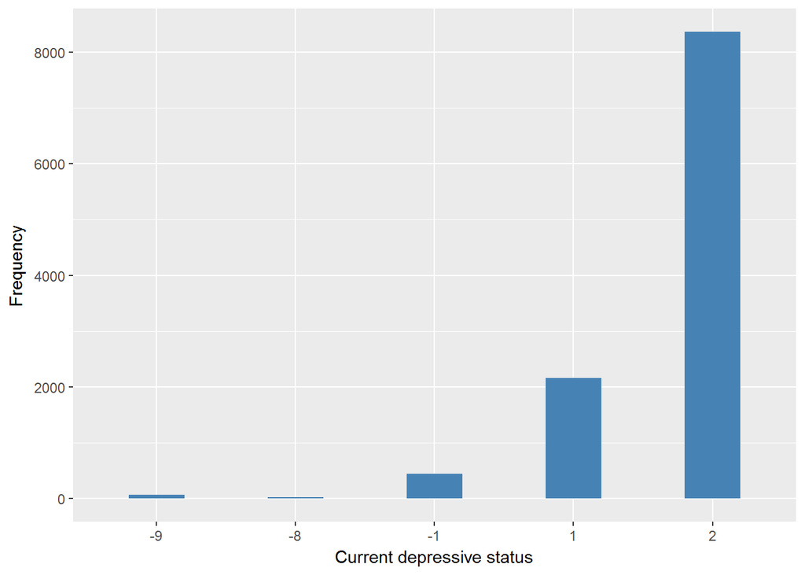

Current depressive status

| Sample size | Missing values |
| --- | --- |
| 11050 | 446 |

Category

|  | -9 | -8 | 1 | 2 |
| --- | --- | --- | --- | --- |
| Frequency | 61.00 | 21.00 | 2083.00 | 8439.00 |
| Percentage | 0.55 | 0.19 | 18.85 | 76.37 |

Type of missing

|  | -17 | -1 | -2 | NA |
| --- | --- | --- | --- | --- |
| Frequency | 0 | 446.00 | 0 | 0 |
| Percentage | 0 | 4.04 | 0 | 0 |

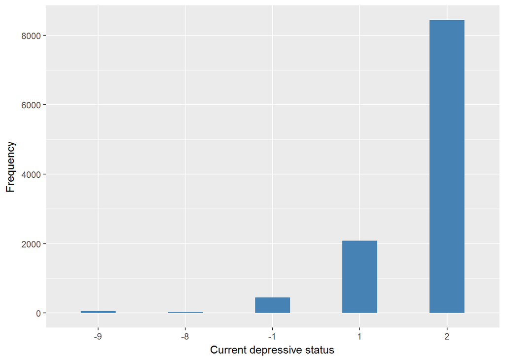

#### 2.1.4.2 Harmonisation algorithm

To compute the harmonized variable from the study-specific variable it has to be recoded as follows:

First of all:

- The reversed items pscedd, pscedf:
  - `recode 1 into 0`
  - `recode 2 into 1`
- The direct items psceda, pscedb, pscedc, pscede, pscedg, pscedh:
  - `keep 1 into 1`
  - `recode 2 into 0`

Secondly in order to get the final score the items have to be summed. If one items is missing, scores on the completed items are summed; the total is divided by the number of items answered and multiplied by 8. If more than 1 items are missing the individual get a missing value in the final score.

After get the final score, it has to be recoded as follows:

**R script:**

```r
# reversed items
ELSA_dep$pd <- car::recode(ELSA_dep$pscedd, "1=0; 2=1; -8=NA; -9=NA; -1=NA; -2=NA")
ELSA_dep$pf <- car::recode(ELSA_dep$pscedf, "1=0; 2=1; -8=NA; -9=NA; -1=NA; -2=NA")

# direct items
ELSA_dep$pa <- car::recode(ELSA_dep$psceda, "2=0; -8=NA; -9=NA; -1=NA; -2=NA")
ELSA_dep$pb <- car::recode(ELSA_dep$pscedb, "2=0; -8=NA; -9=NA; -1=NA; -2=NA")
ELSA_dep$pc <- car::recode(ELSA_dep$pscedc, "2=0; -8=NA; -9=NA; -1=NA; -2=NA")
ELSA_dep$pe <- car::recode(ELSA_dep$pscede, "2=0; -8=NA; -9=NA; -1=NA; -2=NA")
ELSA_dep$pg <- car::recode(ELSA_dep$pscedg, "2=0; -8=NA; -9=NA; -1=NA; -2=NA")
ELSA_dep$ph <- car::recode(ELSA_dep$pscedh, "2=0; -8=NA; -9=NA; -1=NA; -2=NA")


ELSA_dep$nmiss <- apply(ELSA_dep[, 10:17], MARGIN = 1, FUN = function(x) sum(is.na(x)))


ELSA_dep$final_score <- apply(ELSA_dep[, 10:17], MARGIN = 1, FUN = function(x) sum(x,
    na.rm = TRUE))


ELSA_dep$final_score[which(ELSA_dep$nmiss == 1)] <- (ELSA_dep$final_score[which(ELSA_dep$nmiss ==
    1)]/7) * 8

ELSA_dep$n8 <- apply(ELSA_dep[, 2:9], MARGIN = 1, FUN = function(x) sum(x ==
    (-8), na.rm = TRUE))
ELSA_dep$n9 <- apply(ELSA_dep[, 2:9], MARGIN = 1, FUN = function(x) sum(x ==
    (-9), na.rm = TRUE))
ELSA_dep$n12 <- apply(ELSA_dep[, 2:9], MARGIN = 1, FUN = function(x) sum(x %in%
    c(-1, -2), na.rm = TRUE))
ELSA_dep$nNA <- apply(ELSA_dep[, 2:9], MARGIN = 1, FUN = function(x) sum(is.na(x)))

ELSA_dep$max_891_NA <- apply(ELSA_dep[, 20:22], MARGIN = 1, FUN = function(x) which.max(x))
ELSA_dep$max_891_NA <- car::recode(ELSA_dep$max_891_NA, "1=998;2=997;3=996;4=999")

ELSA_dep$final_score[which(ELSA_dep$nmiss > 1)] <- ELSA_dep$max_891_NA[which(ELSA_dep$nmiss >
    1)]

ELSA_ds_w4 <- tibble(id = ELSA_dep$id)
ELSA_ds_w4$depression <- car::recode(ELSA_dep$final_score, "0:3.99999999=0; 4:900=1")
ELSA_ds_w4$depression <- labelled(ELSA_ds_w4[[2]], labels = c(`no depression` = 0,
    depression = 1, Missing = 999, `Do not know` = 998, Refuse = 997, `Not applicable` = 996,
    `Does not answer` = 995, `Not attempt not done` = 994, `Disable to measure` = 993,
    Impute = 992, `CAPI interviewer error` = 991))
```

#### 2.1.4.3 Statistical description of the new harmonised variable

Current depressive status

| Sample size | Missing values |
| --- | --- |
| 11050 | 532 |

Category

|  | 0 | 1 |
| --- | --- | --- |
| Frequency | 8950 | 1568.00 |
| Percentage | 81 | 14.19 |

Type of missing

|  | 991 | 992 | 993 | 994 | 995 | 996 | 997 | 998 | 999 | NA |
| --- | --- | --- | --- | --- | --- | --- | --- | --- | --- | --- |
| Frequency | 0 | 0 | 0 | 0 | 0 | 446.00 | 62.00 | 24.00 | 0 | 0 |
| Percentage | 0 | 0 | 0 | 0 | 0 | 4.04 | 0.56 | 0.22 | 0 | 0 |

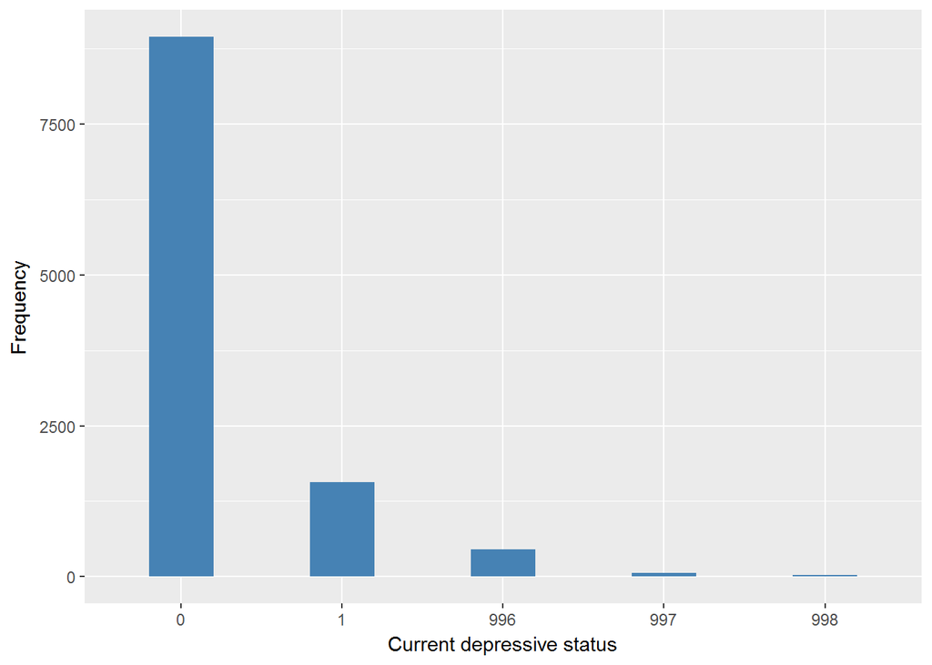

#### 2.1.4.4 Validation

|  | <4->0 | >=4->1 | (-1,-2)->996 | -9->997 | -8->998 |
| --- | --- | --- | --- | --- | --- |
| BeforeH | 8950 | 1568 | 446 | 62 | 24 |
| AfterH | 8950 | 1568 | 446 | 62 | 24 |

### 2.1.5 Wave 5

#### 2.1.5.1 Study-specific variable description

| **Name** | `psceda` | `pscedb` | `pscedc` | `pscedd` | `pscede` | `pscedf` | `pscedg` | `pscedh` |
| --- | --- | --- | --- | --- | --- | --- | --- | --- |
| **Label** | `Whether respondent has felt depressed much of the time during the past week` | `Whether respondent felt everything they did during the past week was an effort` | `Whether respondent felt their sleep was restless during the past week` | `Whether respondent was happy much of the time during the past week` | `Whether respondent felt lonely much of the time during the past week` | `Whether respondent enjoyed life much of the time during the past week` | `Whether respondent felt sad much of the time during the past week` | `Whether respondent could not get going much of the time during the past week` |
| **Table name** | `wave_5_elsa_data_v4` | `wave_5_elsa_data_v4` | `wave_5_elsa_data_v4` | `wave_5_elsa_data_v4` | `wave_5_elsa_data_v4` | `wave_5_elsa_data_v4` | `wave_5_elsa_data_v4` | `wave_5_elsa_data_v4` |
| **Categories** | `1 = yes` | `1 = yes` | `1 = yes` | `1 = yes` | `1 = yes` | `1 = yes` | `1 = yes` | `1 = yes` |
|  | `2 = no` | `2 = no` | `2 = no` | `2 = no` | `2 = no` | `2 = no` | `2 = no` | `2 = no` |
| **Missing** | `-9 = Refusal` | `-9 = Refusal` | `-9 = Refusal` | `-9 = Refusal` | `-9 = Refusal` | `-9 = Refusal` | `-9 = Refusal` | `-9 = Refusal` |
|  | `-8 = Don't Know` | `-8 = Don't Know` | `-8 = Don't Know` | `-8 = Don't Know` | `-8 = Don't Know` | `-8 = Don't Know` | `-8 = Don't Know` | `-8 = Don't Know` |
|  | `-1 = Not applicable` | `-1 = Not applicable` | `-1 = Not applicable` | `-1 = Not applicable` | `-1 = Not applicable` | `-1 = Not applicable` | `-1 = Not applicable` | `-1 = Not applicable` |
|  | `-2 = Schedule not applicable` | `-2 = Schedule not applicable` | `-2 = Schedule not applicable` | `-2 = Schedule not applicable` | `-2 = Schedule not applicable` | `-2 = Schedule not applicable` | `-2 = Schedule not applicable` | `-2 = Schedule not applicable` |
| **Description** |  |  |  |  |  |  |  |  |

Current depressive status

| Sample size | Missing values |
| --- | --- |
| 10274 | 537 |

Category

|  | -9 | -8 | 1 | 2 |
| --- | --- | --- | --- | --- |
| Frequency | 24.00 | 64.00 | 1390.00 | 8259.00 |
| Percentage | 0.23 | 0.62 | 13.53 | 80.39 |

Type of missing

|  | -17 | -1 | -2 | NA |
| --- | --- | --- | --- | --- |
| Frequency | 0 | 537.00 | 0 | 0 |
| Percentage | 0 | 5.23 | 0 | 0 |

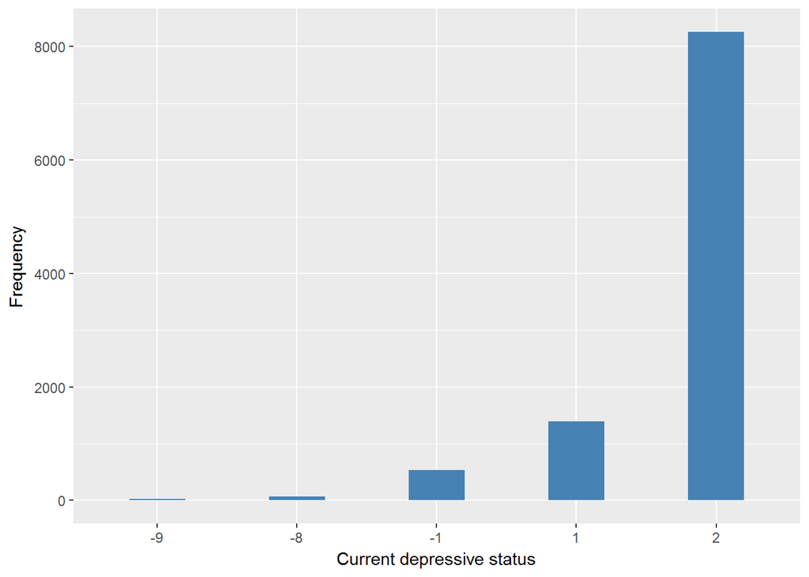

Current depressive status

| Sample size | Missing values |
| --- | --- |
| 10274 | 537 |

Category

|  | -9 | -8 | 1 | 2 |
| --- | --- | --- | --- | --- |
| Frequency | 25.00 | 63.00 | 2028.00 | 7621.00 |
| Percentage | 0.24 | 0.61 | 19.74 | 74.18 |

Type of missing

|  | -17 | -1 | -2 | NA |
| --- | --- | --- | --- | --- |
| Frequency | 0 | 537.00 | 0 | 0 |
| Percentage | 0 | 5.23 | 0 | 0 |

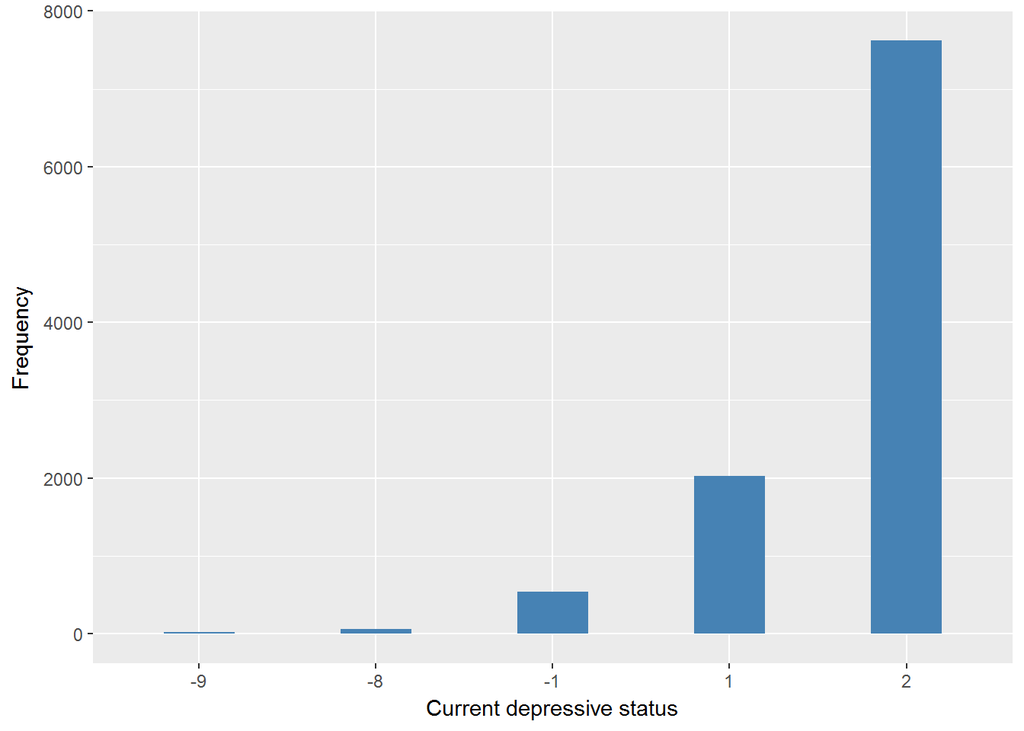

Current depressive status

| Sample size | Missing values |
| --- | --- |
| 10274 | 537 |

Category

|  | -9 | -8 | 1 | 2 |
| --- | --- | --- | --- | --- |
| Frequency | 25.00 | 64.00 | 3980.00 | 5668.00 |
| Percentage | 0.24 | 0.62 | 38.74 | 55.17 |

Type of missing

|  | -17 | -1 | -2 | NA |
| --- | --- | --- | --- | --- |
| Frequency | 0 | 537.00 | 0 | 0 |
| Percentage | 0 | 5.23 | 0 | 0 |

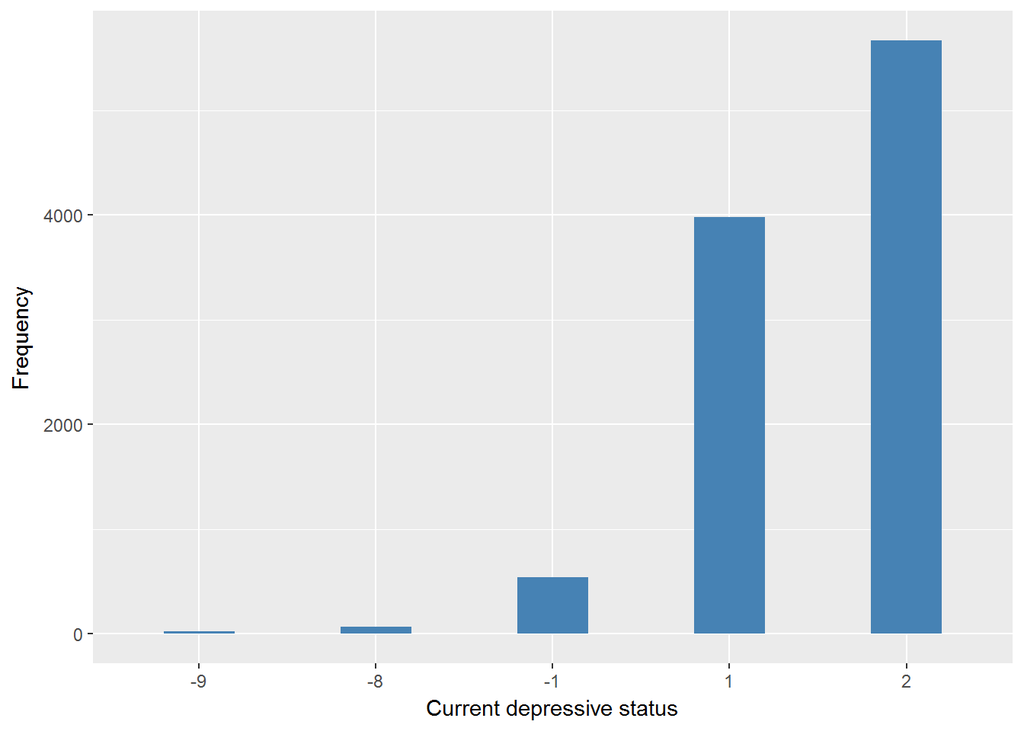

Current depressive status

| Sample size | Missing values |
| --- | --- |
| 10274 | 537 |

Category

|  | -9 | -8 | 1 | 2 |
| --- | --- | --- | --- | --- |
| Frequency | 25.00 | 90.00 | 8616.00 | 1006.00 |
| Percentage | 0.24 | 0.88 | 83.86 | 9.79 |

Type of missing

|  | -17 | -1 | -2 | NA |
| --- | --- | --- | --- | --- |
| Frequency | 0 | 537.00 | 0 | 0 |
| Percentage | 0 | 5.23 | 0 | 0 |

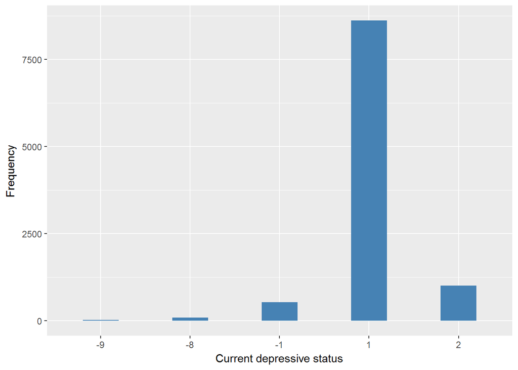

Current depressive status

| Sample size | Missing values |
| --- | --- |
| 10274 | 537 |

Category

|  | -9 | -8 | 1 | 2 |
| --- | --- | --- | --- | --- |
| Frequency | 25.00 | 62.0 | 1253.0 | 8397.00 |
| Percentage | 0.24 | 0.6 | 12.2 | 81.73 |

Type of missing

|  | -17 | -1 | -2 | NA |
| --- | --- | --- | --- | --- |
| Frequency | 0 | 537.00 | 0 | 0 |
| Percentage | 0 | 5.23 | 0 | 0 |

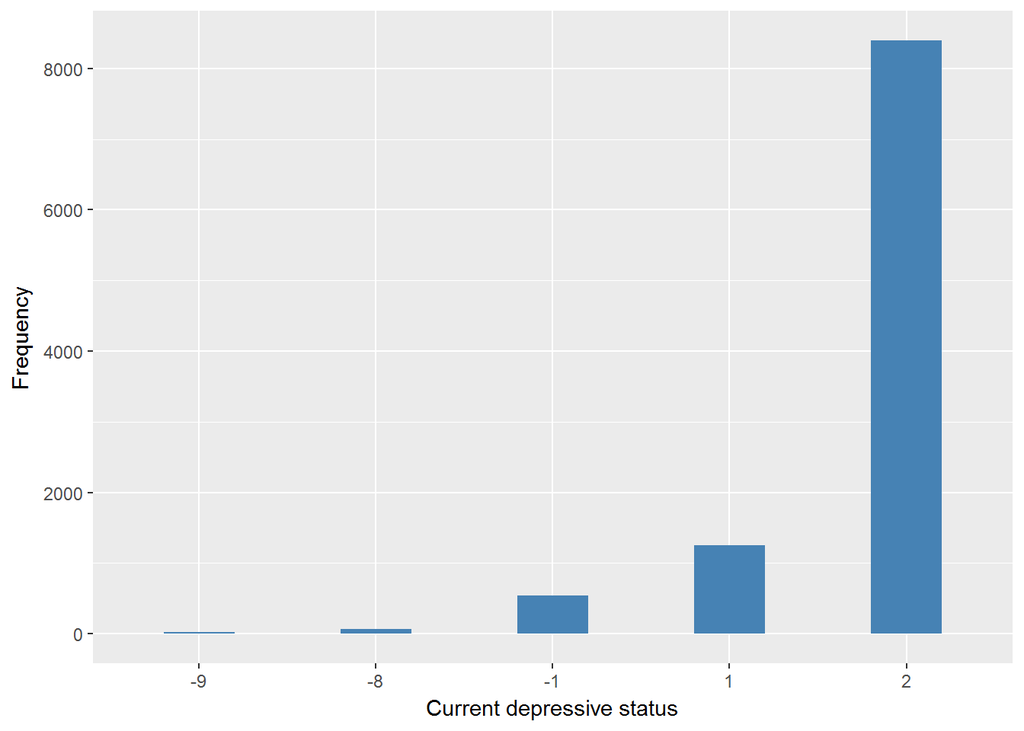

Current depressive status

| Sample size | Missing values |
| --- | --- |
| 10274 | 537 |

Category

|  | -9 | -8 | 1 | 2 |
| --- | --- | --- | --- | --- |
| Frequency | 25.00 | 88.00 | 8669.00 | 955.0 |
| Percentage | 0.24 | 0.86 | 84.38 | 9.3 |

Type of missing

|  | -17 | -1 | -2 | NA |
| --- | --- | --- | --- | --- |
| Frequency | 0 | 537.00 | 0 | 0 |
| Percentage | 0 | 5.23 | 0 | 0 |

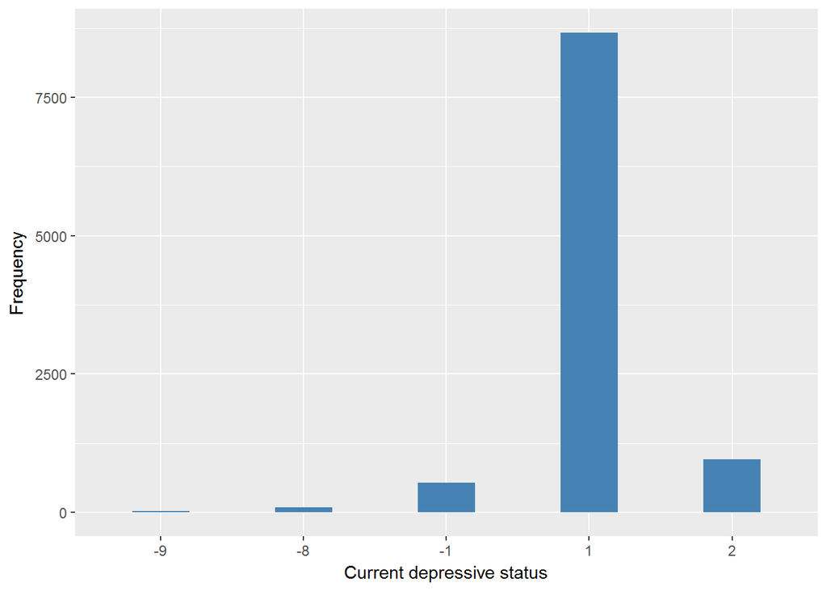

Current depressive status

| Sample size | Missing values |
| --- | --- |
| 10274 | 537 |

Category

|  | -9 | -8 | 1 | 2 |
| --- | --- | --- | --- | --- |
| Frequency | 25.00 | 65.00 | 2032.00 | 7615.00 |
| Percentage | 0.24 | 0.63 | 19.78 | 74.12 |

Type of missing

|  | -17 | -1 | -2 | NA |
| --- | --- | --- | --- | --- |
| Frequency | 0 | 537.00 | 0 | 0 |
| Percentage | 0 | 5.23 | 0 | 0 |

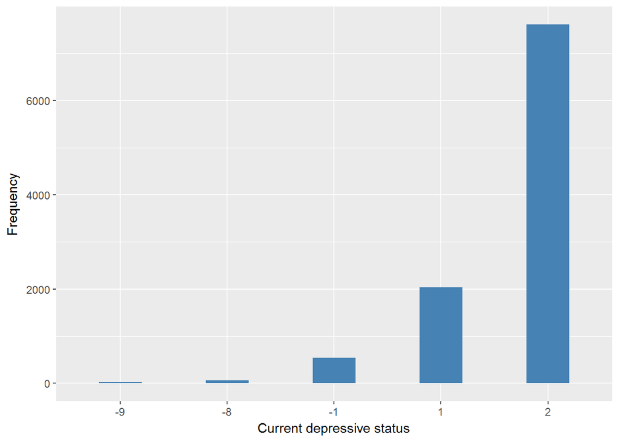

Current depressive status

| Sample size | Missing values |
| --- | --- |
| 10274 | 537 |

Category

|  | -9 | -8 | 1 | 2 |
| --- | --- | --- | --- | --- |
| Frequency | 27.00 | 67.00 | 2068.00 | 7575.00 |
| Percentage | 0.26 | 0.65 | 20.13 | 73.73 |

Type of missing

|  | -17 | -1 | -2 | NA |
| --- | --- | --- | --- | --- |
| Frequency | 0 | 537.00 | 0 | 0 |
| Percentage | 0 | 5.23 | 0 | 0 |

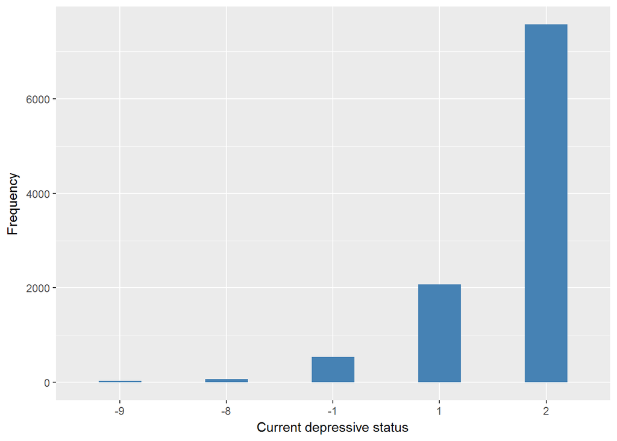

#### 2.1.5.2 Harmonisation algorithm

To compute the harmonized variable from the study-specific variable it has to be recoded as follows:

First of all:

- The reversed items pscedd, pscedf:
  - `recode 1 into 0`
  - `recode 2 into 1`
- The direct items psceda, pscedb, pscedc, pscede, pscedg, pscedh:
  - `keep 1 into 1`
  - `recode 2 into 0`

Secondly in order to get the final score the items have to be summed. If one items is missing, scores on the completed items are summed; the total is divided by the number of items answered and multiplied by 8. If more than 1 items are missing the individual get a missing value in the final score.

After get the final score, it has to be recoded as follows:

**R script:**

```r
# reversed items
ELSA_dep$pd <- car::recode(ELSA_dep$pscedd, "1=0; 2=1; -8=NA; -9=NA; -1=NA; -2=NA")
ELSA_dep$pf <- car::recode(ELSA_dep$pscedf, "1=0; 2=1; -8=NA; -9=NA; -1=NA; -2=NA")

# direct items
ELSA_dep$pa <- car::recode(ELSA_dep$psceda, "2=0; -8=NA; -9=NA; -1=NA; -2=NA")
ELSA_dep$pb <- car::recode(ELSA_dep$pscedb, "2=0; -8=NA; -9=NA; -1=NA; -2=NA")
ELSA_dep$pc <- car::recode(ELSA_dep$pscedc, "2=0; -8=NA; -9=NA; -1=NA; -2=NA")
ELSA_dep$pe <- car::recode(ELSA_dep$pscede, "2=0; -8=NA; -9=NA; -1=NA; -2=NA")
ELSA_dep$pg <- car::recode(ELSA_dep$pscedg, "2=0; -8=NA; -9=NA; -1=NA; -2=NA")
ELSA_dep$ph <- car::recode(ELSA_dep$pscedh, "2=0; -8=NA; -9=NA; -1=NA; -2=NA")


ELSA_dep$nmiss <- apply(ELSA_dep[, 10:17], MARGIN = 1, FUN = function(x) sum(is.na(x)))


ELSA_dep$final_score <- apply(ELSA_dep[, 10:17], MARGIN = 1, FUN = function(x) sum(x,
    na.rm = TRUE))


ELSA_dep$final_score[which(ELSA_dep$nmiss == 1)] <- (ELSA_dep$final_score[which(ELSA_dep$nmiss ==
    1)]/7) * 8

ELSA_dep$n8 <- apply(ELSA_dep[, 2:9], MARGIN = 1, FUN = function(x) sum(x ==
    (-8), na.rm = TRUE))
ELSA_dep$n9 <- apply(ELSA_dep[, 2:9], MARGIN = 1, FUN = function(x) sum(x ==
    (-9), na.rm = TRUE))
ELSA_dep$n12 <- apply(ELSA_dep[, 2:9], MARGIN = 1, FUN = function(x) sum(x %in%
    c(-1, -2), na.rm = TRUE))
ELSA_dep$nNA <- apply(ELSA_dep[, 2:9], MARGIN = 1, FUN = function(x) sum(is.na(x)))

ELSA_dep$max_891_NA <- apply(ELSA_dep[, 20:22], MARGIN = 1, FUN = function(x) which.max(x))
ELSA_dep$max_891_NA <- car::recode(ELSA_dep$max_891_NA, "1=998;2=997;3=996;4=999")

ELSA_dep$final_score[which(ELSA_dep$nmiss > 1)] <- ELSA_dep$max_891_NA[which(ELSA_dep$nmiss >
    1)]

ELSA_ds_w5 <- tibble(id = ELSA_dep$id)
ELSA_ds_w5$depression <- car::recode(ELSA_dep$final_score, "0:3.99999999=0; 4:900=1")
ELSA_ds_w5$depression <- labelled(ELSA_ds_w5[[2]], labels = c(`no depression` = 0,
    depression = 1, Missing = 999, `Do not know` = 998, Refuse = 997, `Not applicable` = 996,
    `Does not answer` = 995, `Not attempt not done` = 994, `Disable to measure` = 993,
    Impute = 992, `CAPI interviewer error` = 991))
```

#### 2.1.5.3 Statistical description of the new harmonised variable

Current depressive status

| Sample size | Missing values |
| --- | --- |
| 10274 | 633 |

Category

|  | 0 | 1 |
| --- | --- | --- |
| Frequency | 8179.00 | 1462.00 |
| Percentage | 79.61 | 14.23 |

Type of missing

|  | 991 | 992 | 993 | 994 | 995 | 996 | 997 | 998 | 999 | NA |
| --- | --- | --- | --- | --- | --- | --- | --- | --- | --- | --- |
| Frequency | 0 | 0 | 0 | 0 | 0 | 537.00 | 25.00 | 71.00 | 0 | 0 |
| Percentage | 0 | 0 | 0 | 0 | 0 | 5.23 | 0.24 | 0.69 | 0 | 0 |

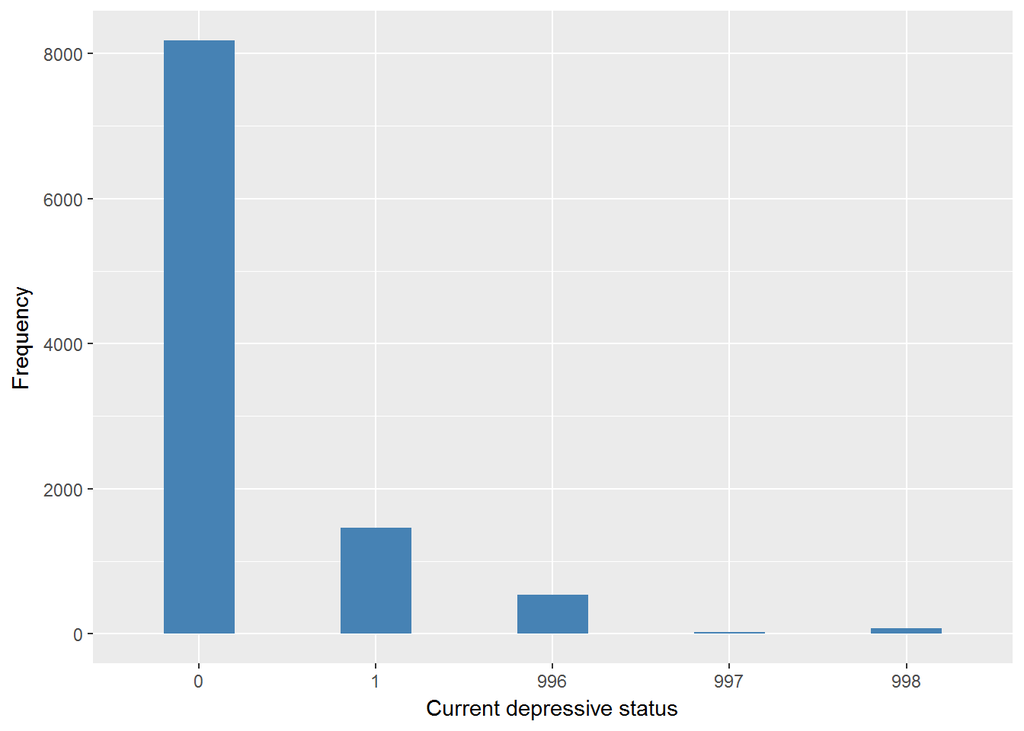

#### 2.1.5.4 Validation

|  | <4->0 | >=4->1 | (-1,-2)->996 | -9->997 | -8->998 |
| --- | --- | --- | --- | --- | --- |
| BeforeH | 8179 | 1462 | 537 | 25 | 71 |
| AfterH | 8179 | 1462 | 537 | 25 | 71 |

### 2.1.6 Wave 6

#### 2.1.6.1 Study-specific variable description

| **Name** | `PScedA` | `PScedB` | `PScedC` | `PScedD` | `PScedE` | `PScedF` | `PScedG` | `PScedH` |
| --- | --- | --- | --- | --- | --- | --- | --- | --- |
| **Label** | `Whether respondent has felt depressed much of the time during the past week` | `Whether respondent felt everything they did during the past week was an effort` | `Whether respondent felt their sleep was restless during the past week` | `Whether respondent was happy much of the time during the past week` | `Whether respondent felt lonely much of the time during the past week` | `Whether respondent enjoyed life much of the time during the past week` | `Whether respondent felt sad much of the time during the past week` | `Whether respondent could not get going much of the time during the past week` |
| **Table name** | `wave_6_elsa_data_v2` | `wave_6_elsa_data_v2` | `wave_6_elsa_data_v2` | `wave_6_elsa_data_v2` | `wave_6_elsa_data_v2` | `wave_6_elsa_data_v2` | `wave_6_elsa_data_v2` | `wave_6_elsa_data_v2` |
| **Categories** | `1 = yes` | `1 = yes` | `1 = yes` | `1 = yes` | `1 = yes` | `1 = yes` | `1 = yes` | `1 = yes` |
|  | `2 = no` | `2 = no` | `2 = no` | `2 = no` | `2 = no` | `2 = no` | `2 = no` | `2 = no` |
| **Missing** | `-9 = Refusal` | `-9 = Refusal` | `-9 = Refusal` | `-9 = Refusal` | `-9 = Refusal` | `-9 = Refusal` | `-9 = Refusal` | `-9 = Refusal` |
|  | `-8 = Don't Know` | `-8 = Don't Know` | `-8 = Don't Know` | `-8 = Don't Know` | `-8 = Don't Know` | `-8 = Don't Know` | `-8 = Don't Know` | `-8 = Don't Know` |
|  | `-1 = Not applicable` | `-1 = Not applicable` | `-1 = Not applicable` | `-1 = Not applicable` | `-1 = Not applicable` | `-1 = Not applicable` | `-1 = Not applicable` | `-1 = Not applicable` |
|  | `-2 = Schedule not applicable` | `-2 = Schedule not applicable` | `-2 = Schedule not applicable` | `-2 = Schedule not applicable` | `-2 = Schedule not applicable` | `-2 = Schedule not applicable` | `-2 = Schedule not applicable` | `-2 = Schedule not applicable` |
| **Description** |  |  |  |  |  |  |  |  |

Current depressive status

| Sample size | Missing values |
| --- | --- |
| 10601 | 627 |

Category

|  | -9 | -8 | 1 | 2 |
| --- | --- | --- | --- | --- |
| Frequency | 27.00 | 34.00 | 1293.0 | 8620.00 |
| Percentage | 0.25 | 0.32 | 12.2 | 81.31 |

Type of missing

|  | -17 | -1 | -2 | NA |
| --- | --- | --- | --- | --- |
| Frequency | 0 | 627.00 | 0 | 0 |
| Percentage | 0 | 5.91 | 0 | 0 |

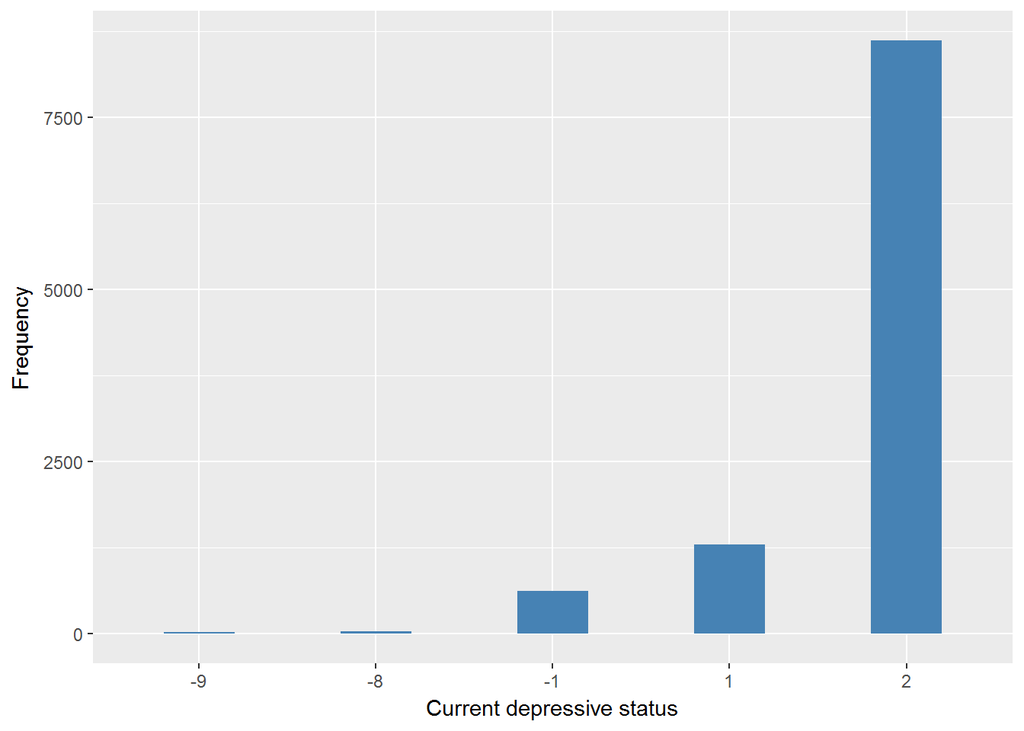

Current depressive status

| Sample size | Missing values |
| --- | --- |
| 10601 | 627 |

Category

|  | -9 | -8 | 1 | 2 |
| --- | --- | --- | --- | --- |
| Frequency | 28.00 | 31.00 | 1911.00 | 8004.0 |
| Percentage | 0.26 | 0.29 | 18.03 | 75.5 |

Type of missing

|  | -17 | -1 | -2 | NA |
| --- | --- | --- | --- | --- |
| Frequency | 0 | 627.00 | 0 | 0 |
| Percentage | 0 | 5.91 | 0 | 0 |

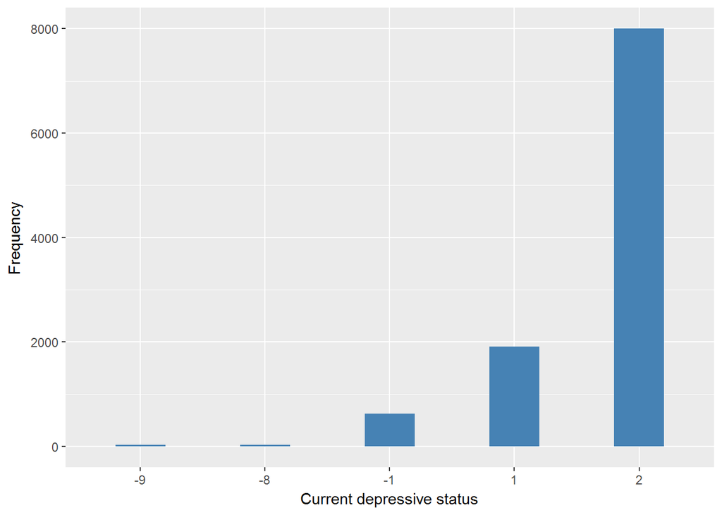

Current depressive status

| Sample size | Missing values |
| --- | --- |
| 10601 | 627 |

Category

|  | -9 | -8 | 1 | 2 |
| --- | --- | --- | --- | --- |
| Frequency | 28.00 | 27.00 | 3428.00 | 6491.00 |
| Percentage | 0.26 | 0.25 | 32.34 | 61.23 |

Type of missing

|  | -17 | -1 | -2 | NA |
| --- | --- | --- | --- | --- |
| Frequency | 0 | 627.00 | 0 | 0 |
| Percentage | 0 | 5.91 | 0 | 0 |

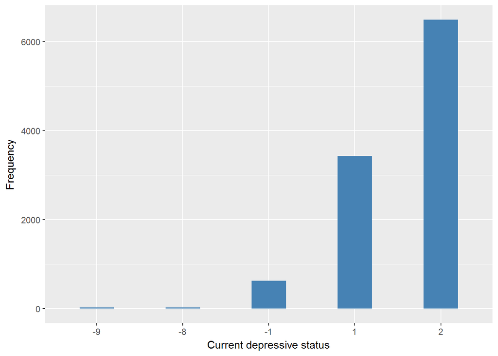

Current depressive status

| Sample size | Missing values |
| --- | --- |
| 10601 | 627 |

Category

|  | -9 | -8 | 1 | 2 |
| --- | --- | --- | --- | --- |
| Frequency | 28.00 | 49.00 | 8840.00 | 1057.00 |
| Percentage | 0.26 | 0.46 | 83.39 | 9.97 |

Type of missing

|  | -17 | -1 | -2 | NA |
| --- | --- | --- | --- | --- |
| Frequency | 0 | 627.00 | 0 | 0 |
| Percentage | 0 | 5.91 | 0 | 0 |

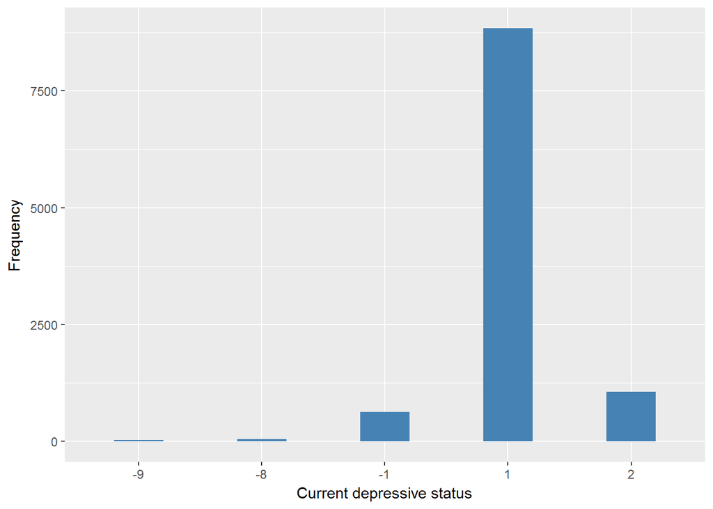

Current depressive status

| Sample size | Missing values |
| --- | --- |
| 10601 | 627 |

Category

|  | -9 | -8 | 1 | 2 |
| --- | --- | --- | --- | --- |
| Frequency | 28.00 | 32.0 | 1146.00 | 8768.00 |
| Percentage | 0.26 | 0.3 | 10.81 | 82.71 |

Type of missing

|  | -17 | -1 | -2 | NA |
| --- | --- | --- | --- | --- |
| Frequency | 0 | 627.00 | 0 | 0 |
| Percentage | 0 | 5.91 | 0 | 0 |

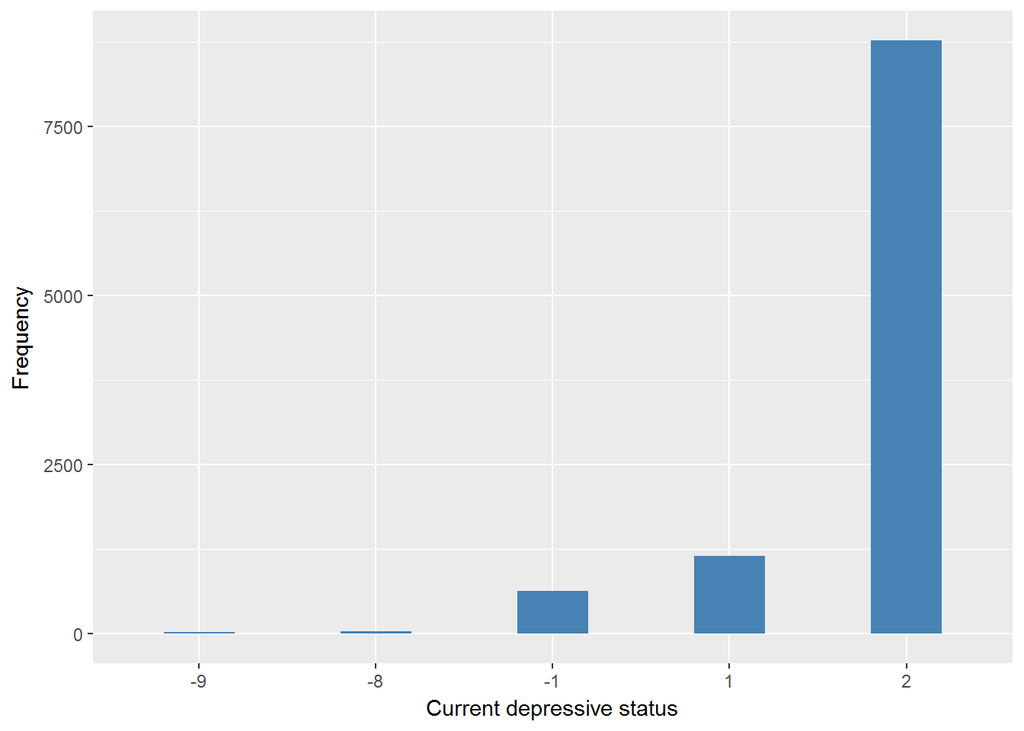

Current depressive status

| Sample size | Missing values |
| --- | --- |
| 10601 | 627 |

Category

|  | -9 | -8 | 1 | 2 |
| --- | --- | --- | --- | --- |
| Frequency | 27.00 | 61.00 | 8902.00 | 984.00 |
| Percentage | 0.25 | 0.58 | 83.97 | 9.28 |

Type of missing

|  | -17 | -1 | -2 | NA |
| --- | --- | --- | --- | --- |
| Frequency | 0 | 627.00 | 0 | 0 |
| Percentage | 0 | 5.91 | 0 | 0 |

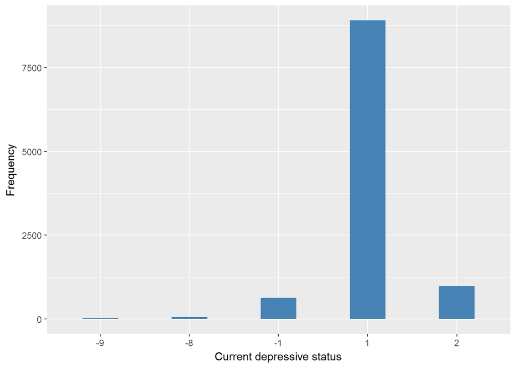

Current depressive status

| Sample size | Missing values |
| --- | --- |
| 10601 | 627 |

Category

|  | -9 | -8 | 1 | 2 |
| --- | --- | --- | --- | --- |
| Frequency | 28.00 | 41.00 | 1825.00 | 8080.00 |
| Percentage | 0.26 | 0.39 | 17.22 | 76.22 |

Type of missing

|  | -17 | -1 | -2 | NA |
| --- | --- | --- | --- | --- |
| Frequency | 0 | 627.00 | 0 | 0 |
| Percentage | 0 | 5.91 | 0 | 0 |

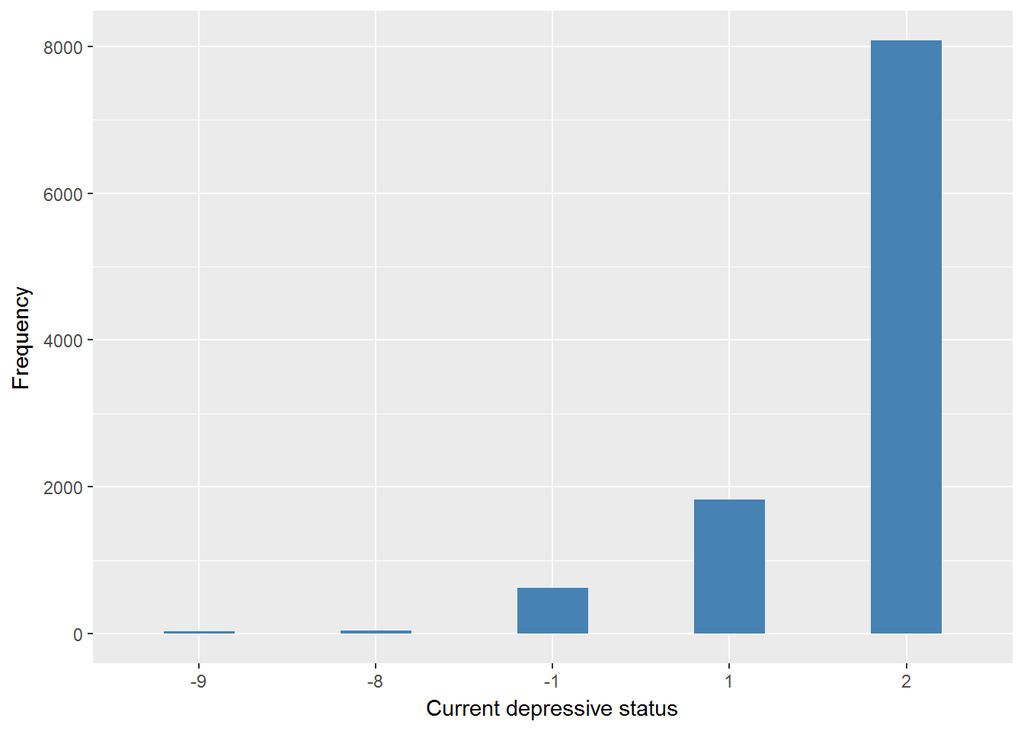

Current depressive status

| Sample size | Missing values |
| --- | --- |
| 10601 | 627 |

Category

|  | -9 | -8 | 1 | 2 |
| --- | --- | --- | --- | --- |
| Frequency | 28.00 | 34.00 | 1854.00 | 8058.00 |
| Percentage | 0.26 | 0.32 | 17.49 | 76.01 |

Type of missing

|  | -17 | -1 | -2 | NA |
| --- | --- | --- | --- | --- |
| Frequency | 0 | 627.00 | 0 | 0 |
| Percentage | 0 | 5.91 | 0 | 0 |

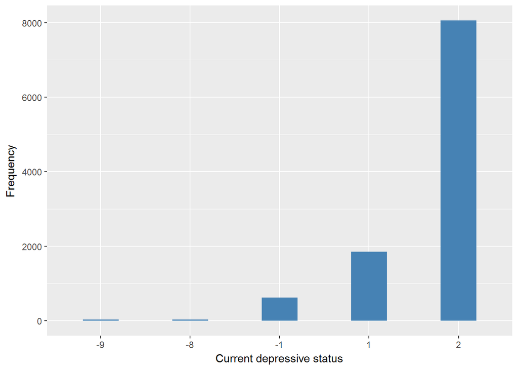

#### 2.1.6.2 Harmonisation algorithm

To compute the harmonized variable from the study-specific variable it has to be recoded as follows:

First of all:

- The reversed items pscedd, pscedf:
  - `recode 1 into 0`
  - `recode 2 into 1`
- The direct items psceda, pscedb, pscedc, pscede, pscedg, pscedh:
  - `keep 1 into 1`
  - `recode 2 into 0`

Secondly in order to get the final score the items have to be summed. If one items is missing, scores on the completed items are summed; the total is divided by the number of items answered and multiplied by 8. If more than 1 items are missing the individual get a missing value in the final score.

After get the final score, it has to be recoded as follows:

- `0-3 into 0`
- `>4 into 1`
- `NA into`
  - `997 if the individual has more items = -9 than -8, -1, -2 and NA`
  - `998 if the individual has more items = -8 than -9, -1, -2 and NA`
  - `996 if the individual has more items = -1 and -2 than -9, -8 and NA`
  - `999 if the individual has more items = NA than -8, -9, -2 and -1`

**R script:**

```r
# reversed items
ELSA_dep$pd <- car::recode(ELSA_dep$PScedD, "1=0; 2=1; -8=NA; -9=NA; -1=NA; -2=NA")
ELSA_dep$pf <- car::recode(ELSA_dep$PScedF, "1=0; 2=1; -8=NA; -9=NA; -1=NA; -2=NA")

# direct items
ELSA_dep$pa <- car::recode(ELSA_dep$PScedA, "2=0; -8=NA; -9=NA; -1=NA; -2=NA")
ELSA_dep$pb <- car::recode(ELSA_dep$PScedB, "2=0; -8=NA; -9=NA; -1=NA; -2=NA")
ELSA_dep$pc <- car::recode(ELSA_dep$PScedC, "2=0; -8=NA; -9=NA; -1=NA; -2=NA")
ELSA_dep$pe <- car::recode(ELSA_dep$PScedE, "2=0; -8=NA; -9=NA; -1=NA; -2=NA")
ELSA_dep$pg <- car::recode(ELSA_dep$PScedG, "2=0; -8=NA; -9=NA; -1=NA; -2=NA")
ELSA_dep$ph <- car::recode(ELSA_dep$PScedH, "2=0; -8=NA; -9=NA; -1=NA; -2=NA")


ELSA_dep$nmiss <- apply(ELSA_dep[, 10:17], MARGIN = 1, FUN = function(x) sum(is.na(x)))


ELSA_dep$final_score <- apply(ELSA_dep[, 10:17], MARGIN = 1, FUN = function(x) sum(x,
    na.rm = TRUE))


ELSA_dep$final_score[which(ELSA_dep$nmiss == 1)] <- (ELSA_dep$final_score[which(ELSA_dep$nmiss ==
    1)]/7) * 8

ELSA_dep$n8 <- apply(ELSA_dep[, 2:9], MARGIN = 1, FUN = function(x) sum(x ==
    (-8), na.rm = TRUE))
ELSA_dep$n9 <- apply(ELSA_dep[, 2:9], MARGIN = 1, FUN = function(x) sum(x ==
    (-9), na.rm = TRUE))
ELSA_dep$n12 <- apply(ELSA_dep[, 2:9], MARGIN = 1, FUN = function(x) sum(x %in%
    c(-1, -2), na.rm = TRUE))
ELSA_dep$nNA <- apply(ELSA_dep[, 2:9], MARGIN = 1, FUN = function(x) sum(is.na(x)))

ELSA_dep$max_891_NA <- apply(ELSA_dep[, 20:22], MARGIN = 1, FUN = function(x) which.max(x))
ELSA_dep$max_891_NA <- car::recode(ELSA_dep$max_891_NA, "1=998;2=997;3=996;4=999")

ELSA_dep$final_score[which(ELSA_dep$nmiss > 1)] <- ELSA_dep$max_891_NA[which(ELSA_dep$nmiss >
    1)]

ELSA_ds_w6 <- tibble(id = ELSA_dep$id)
ELSA_ds_w6$depression <- car::recode(ELSA_dep$final_score, "0:3.99999999=0; 4:900=1")
ELSA_ds_w6$depression <- labelled(ELSA_ds_w6[[2]], labels = c(`no depression` = 0,
    depression = 1, Missing = 999, `Do not know` = 998, Refuse = 997, `Not applicable` = 996,
    `Does not answer` = 995, `Not attempt not done` = 994, `Disable to measure` = 993,
    Impute = 992, `CAPI interviewer error` = 991))
```

#### 2.1.6.3 Statistical description of the new harmonised variable

Current depressive status

| Sample size | Missing values |
| --- | --- |
| 10601 | 696 |

Category

|  | 0 | 1 |
| --- | --- | --- |
| Frequency | 8572.00 | 1333.00 |
| Percentage | 80.86 | 12.57 |

Type of missing

|  | 991 | 992 | 993 | 994 | 995 | 996 | 997 | 998 | 999 | NA |
| --- | --- | --- | --- | --- | --- | --- | --- | --- | --- | --- |
| Frequency | 0 | 0 | 0 | 0 | 0 | 627.00 | 28.00 | 41.00 | 0 | 0 |
| Percentage | 0 | 0 | 0 | 0 | 0 | 5.91 | 0.26 | 0.39 | 0 | 0 |

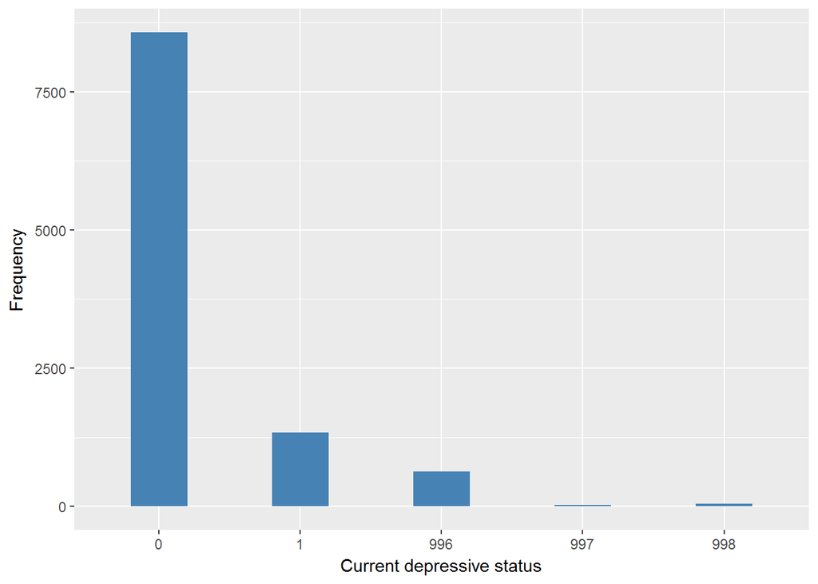

#### 2.1.6.4 Validation

|  | <4->0 | >=4->1 | (-1,-2)->996 | -9->997 | -8->998 |
| --- | --- | --- | --- | --- | --- |
| BeforeH | 8572 | 1333 | 627 | 28 | 41 |
| AfterH | 8572 | 1333 | 627 | 28 | 41 |

### 2.1.7 Wave 7

#### 2.1.7.1 Study-specific variable description

| **Name** | `PScedA` | `PScedB` | `PScedC` | `PScedD` | `PScedE` | `PScedF` | `PScedG` | `PScedH` |
| --- | --- | --- | --- | --- | --- | --- | --- | --- |
| **Label** | `Whether respondent has felt depressed much of the time during the past week` | `Whether respondent felt everything they did during the past week was an effort` | `Whether respondent felt their sleep was restless during the past week` | `Whether respondent was happy much of the time during the past week` | `Whether respondent felt lonely much of the time during the past week` | `Whether respondent enjoyed life much of the time during the past week` | `Whether respondent felt sad much of the time during the past week` | `Whether respondent could not get going much of the time during the past week` |
| **Table name** | `wave_7_elsa_data` | `wave_7_elsa_data` | `wave_7_elsa_data` | `wave_7_elsa_data` | `wave_7_elsa_data` | `wave_7_elsa_data` | `wave_7_elsa_data` | `wave_7_elsa_data` |
| **Categories** | `1 = yes` | `1 = yes` | `1 = yes` | `1 = yes` | `1 = yes` | `1 = yes` | `1 = yes` | `1 = yes` |
|  | `2 = no` | `2 = no` | `2 = no` | `2 = no` | `2 = no` | `2 = no` | `2 = no` | `2 = no` |
| **Missing** | `-9 = Refusal` | `-9 = Refusal` | `-9 = Refusal` | `-9 = Refusal` | `-9 = Refusal` | `-9 = Refusal` | `-9 = Refusal` | `-9 = Refusal` |
|  | `-8 = Don't Know` | `-8 = Don't Know` | `-8 = Don't Know` | `-8 = Don't Know` | `-8 = Don't Know` | `-8 = Don't Know` | `-8 = Don't Know` | `-8 = Don't Know` |
|  | `-1 = Not applicable` | `-1 = Not applicable` | `-1 = Not applicable` | `-1 = Not applicable` | `-1 = Not applicable` | `-1 = Not applicable` | `-1 = Not applicable` | `-1 = Not applicable` |
|  | `-2 = Schedule not applicable` | `-2 = Schedule not applicable` | `-2 = Schedule not applicable` | `-2 = Schedule not applicable` | `-2 = Schedule not applicable` | `-2 = Schedule not applicable` | `-2 = Schedule not applicable` | `-2 = Schedule not applicable` |
| **Description** |  |  |  |  |  |  |  |  |

Current depressive status

| Sample size | Missing values |
| --- | --- |
| 9666 | 597 |

Category

|  | -9 | -8 | 1 | 2 |
| --- | --- | --- | --- | --- |
| Frequency | 50.00 | 18.00 | 1043.00 | 7958.00 |
| Percentage | 0.52 | 0.19 | 10.79 | 82.33 |

Type of missing

|  | -17 | -1 | -2 | NA |
| --- | --- | --- | --- | --- |
| Frequency | 0 | 597.00 | 0 | 0 |
| Percentage | 0 | 6.18 | 0 | 0 |

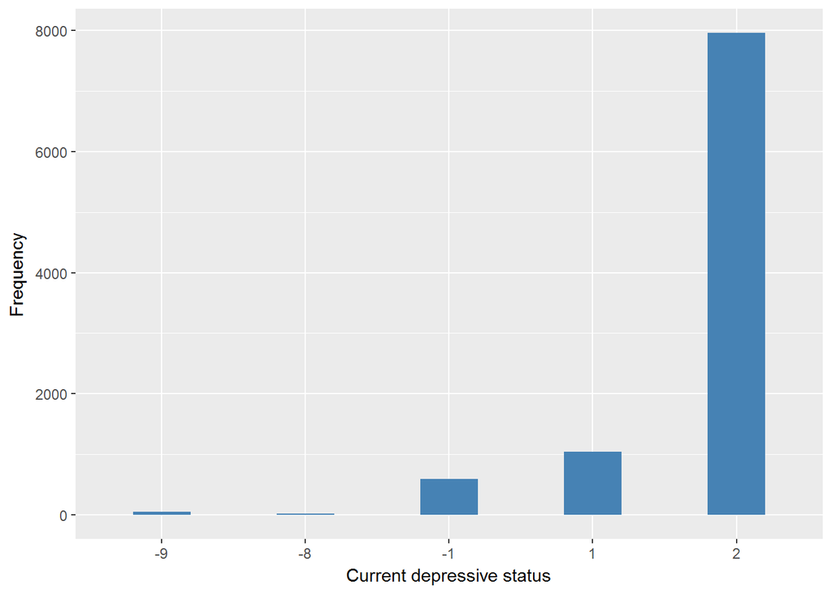

Current depressive status

| Sample size | Missing values |
| --- | --- |
| 9666 | 597 |

Category

|  | -9 | -8 | 1 | 2 |
| --- | --- | --- | --- | --- |
| Frequency | 49.00 | 20.00 | 1696.00 | 7304.00 |
| Percentage | 0.51 | 0.21 | 17.55 | 75.56 |

Type of missing

|  | -17 | -1 | -2 | NA |
| --- | --- | --- | --- | --- |
| Frequency | 0 | 597.00 | 0 | 0 |
| Percentage | 0 | 6.18 | 0 | 0 |

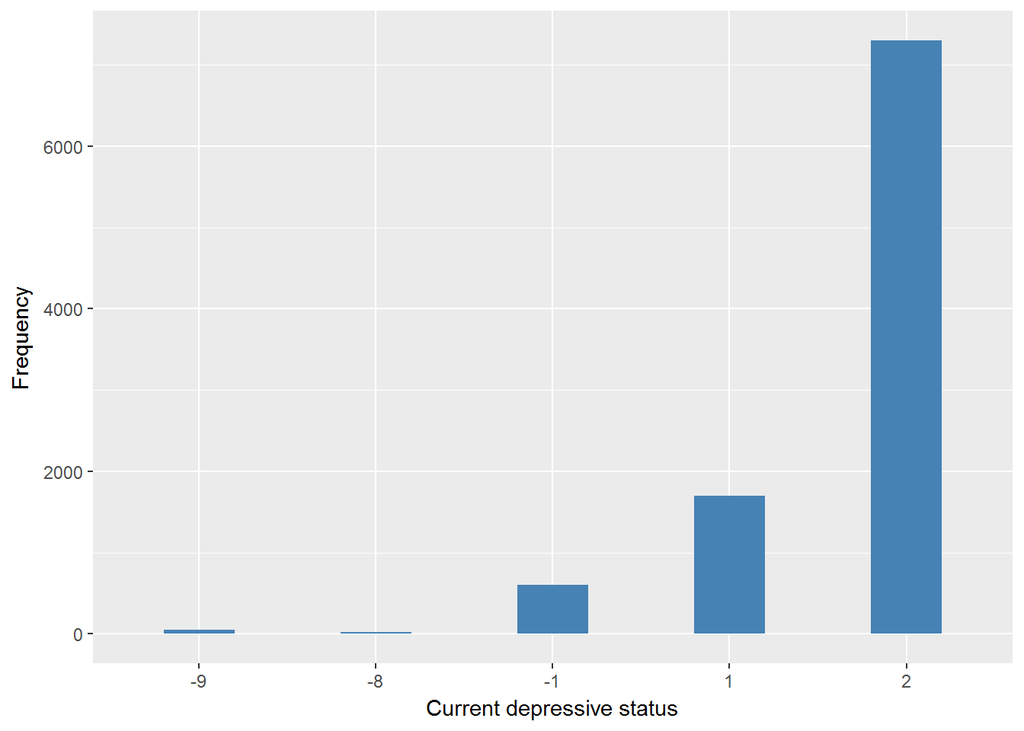

Current depressive status

| Sample size | Missing values |
| --- | --- |
| 9666 | 597 |

Category

|  | -9 | -8 | 1 | 2 |
| --- | --- | --- | --- | --- |
| Frequency | 49.00 | 23.00 | 3663.0 | 5334.00 |
| Percentage | 0.51 | 0.24 | 37.9 | 55.18 |

Type of missing

|  | -17 | -1 | -2 | NA |
| --- | --- | --- | --- | --- |
| Frequency | 0 | 597.00 | 0 | 0 |
| Percentage | 0 | 6.18 | 0 | 0 |

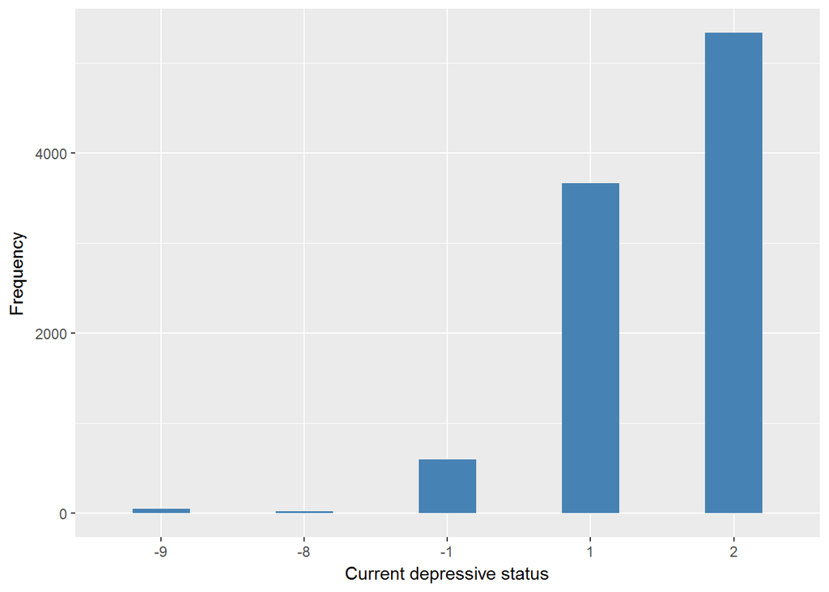

Current depressive status

| Sample size | Missing values |
| --- | --- |
| 9666 | 597 |

Category

|  | -9 | -8 | 1 | 2 |
| --- | --- | --- | --- | --- |
| Frequency | 50.00 | 41.00 | 8109.00 | 869.00 |
| Percentage | 0.52 | 0.42 | 83.89 | 8.99 |

Type of missing

|  | -17 | -1 | -2 | NA |
| --- | --- | --- | --- | --- |
| Frequency | 0 | 597.00 | 0 | 0 |
| Percentage | 0 | 6.18 | 0 | 0 |

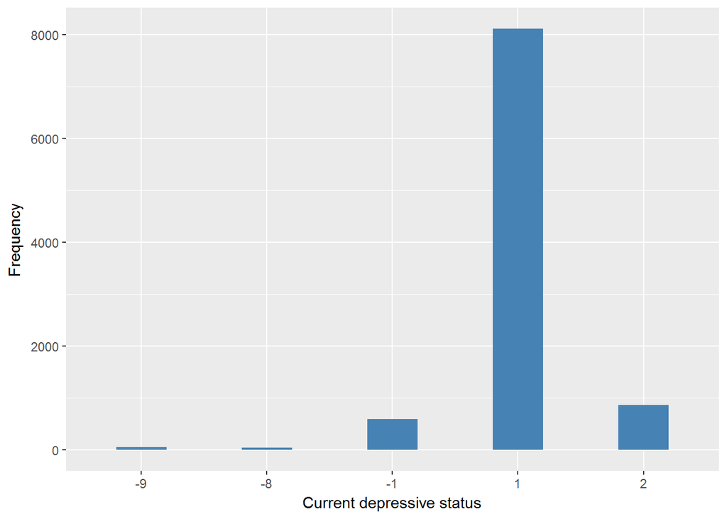

Current depressive status

| Sample size | Missing values |
| --- | --- |
| 9666 | 597 |

Category

|  | -9 | -8 | 1 | 2 |
| --- | --- | --- | --- | --- |
| Frequency | 51.00 | 23.00 | 959.00 | 8036.00 |
| Percentage | 0.53 | 0.24 | 9.92 | 83.14 |

Type of missing

|  | -17 | -1 | -2 | NA |
| --- | --- | --- | --- | --- |
| Frequency | 0 | 597.00 | 0 | 0 |
| Percentage | 0 | 6.18 | 0 | 0 |

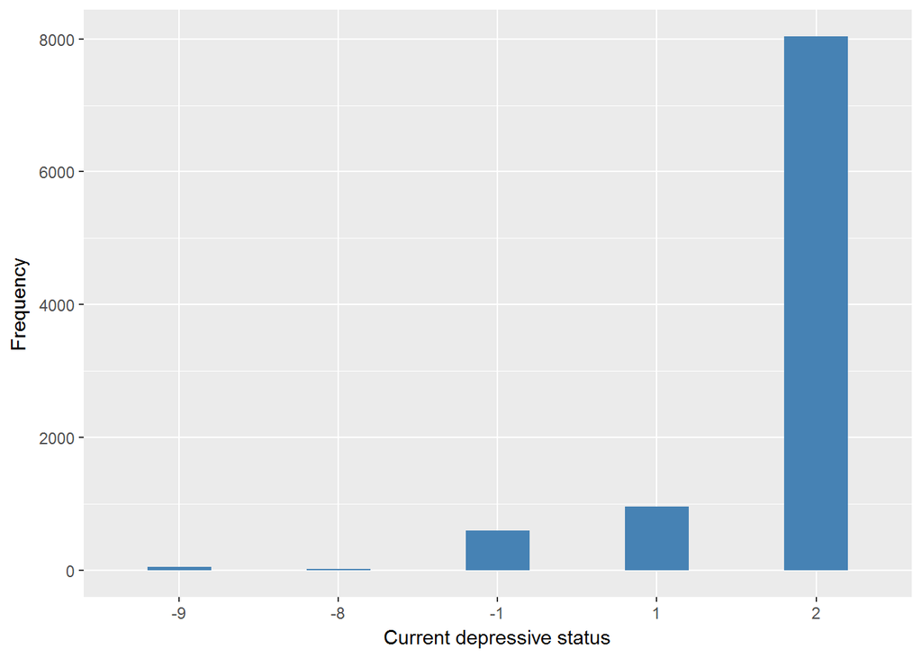

Current depressive status

| Sample size | Missing values |
| --- | --- |
| 9666 | 597 |

Category

|  | -9 | -8 | 1 | 2 |
| --- | --- | --- | --- | --- |
| Frequency | 52.00 | 41.00 | 8177.0 | 799.00 |
| Percentage | 0.54 | 0.42 | 84.6 | 8.27 |

Type of missing

|  | -17 | -1 | -2 | NA |
| --- | --- | --- | --- | --- |
| Frequency | 0 | 597.00 | 0 | 0 |
| Percentage | 0 | 6.18 | 0 | 0 |

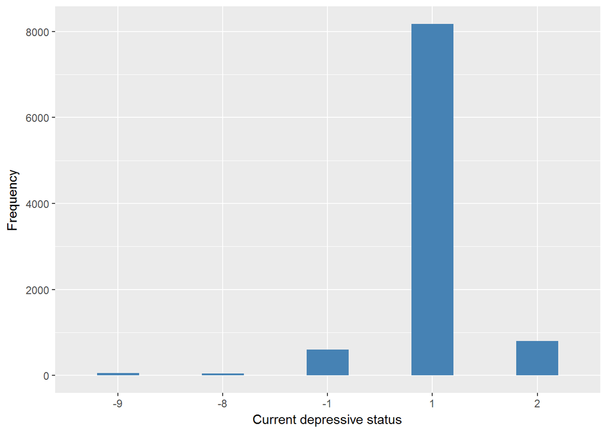

Current depressive status

| Sample size | Missing values |
| --- | --- |
| 9666 | 597 |

Category

|  | -9 | -8 | 1 | 2 |
| --- | --- | --- | --- | --- |
| Frequency | 52.00 | 22.00 | 1535.00 | 7460.00 |
| Percentage | 0.54 | 0.23 | 15.88 | 77.18 |

Type of missing

|  | -17 | -1 | -2 | NA |
| --- | --- | --- | --- | --- |
| Frequency | 0 | 597.00 | 0 | 0 |
| Percentage | 0 | 6.18 | 0 | 0 |

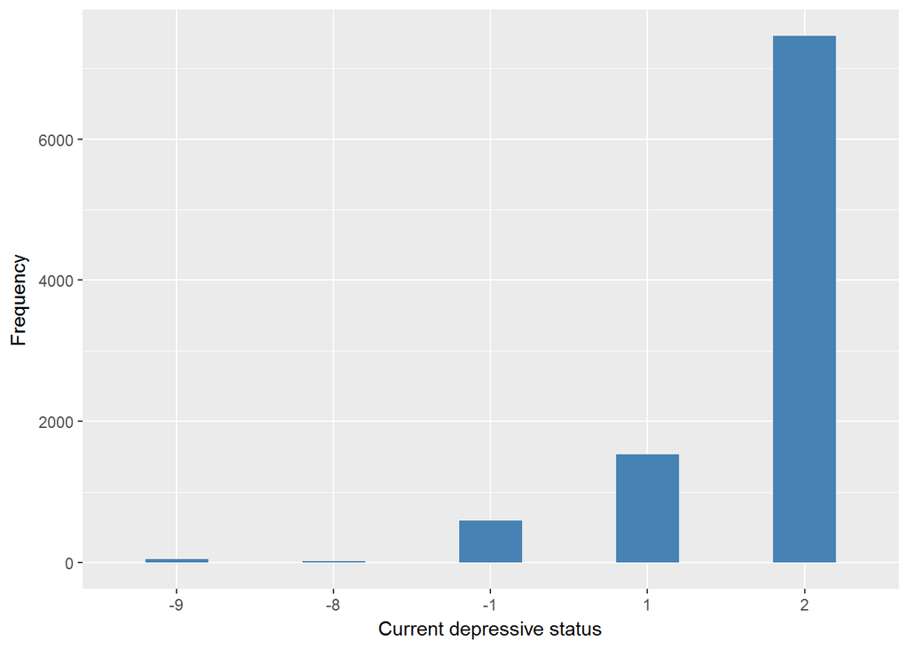

Current depressive status

| Sample size | Missing values |
| --- | --- |
| 9666 | 597 |

Category

|  | -9 | -8 | 1 | 2 |
| --- | --- | --- | --- | --- |
| Frequency | 51.00 | 25.00 | 1708.00 | 7285.00 |
| Percentage | 0.53 | 0.26 | 17.67 | 75.37 |

Type of missing

|  | -17 | -1 | -2 | NA |
| --- | --- | --- | --- | --- |
| Frequency | 0 | 597.00 | 0 | 0 |
| Percentage | 0 | 6.18 | 0 | 0 |

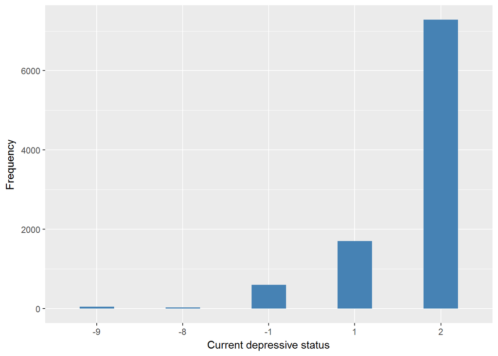

#### 2.1.7.2 Harmonisation algorithm

To compute the harmonized variable from the study-specific variable it has to be recoded as follows:

First of all:

- The reversed items pscedd, pscedf:
  - `recode 1 into 0`
  - `recode 2 into 1`
- The direct items psceda, pscedb, pscedc, pscede, pscedg, pscedh:
  - `keep 1 into 1`
  - `recode 2 into 0`

Secondly in order to get the final score the items have to be summed. If one items is missing, scores on the completed items are summed; the total is divided by the number of items answered and multiplied by 8. If more than 1 items are missing the individual get a missing value in the final score.

After get the final score, it has to be recoded as follows:

- `0-3 into 0`
- `>4 into 1`
- `NA into`
  - `997 if the individual has more items = -9 than -8, -1, -2 and NA`
  - `998 if the individual has more items = -8 than -9, -1, -2 and NA`
  - `996 if the individual has more items = -1 and -2 than -9, -8 and NA`
  - `999 if the individual has more items = NA than -8, -9, -2 and -1`

**R script:**

```r
# reversed items
ELSA_dep$pd <- car::recode(ELSA_dep$PScedD, "1=0; 2=1; -8=NA; -9=NA; -1=NA; -2=NA")
ELSA_dep$pf <- car::recode(ELSA_dep$PScedF, "1=0; 2=1; -8=NA; -9=NA; -1=NA; -2=NA")

# direct items
ELSA_dep$pa <- car::recode(ELSA_dep$PScedA, "2=0; -8=NA; -9=NA; -1=NA; -2=NA")
ELSA_dep$pb <- car::recode(ELSA_dep$PScedB, "2=0; -8=NA; -9=NA; -1=NA; -2=NA")
ELSA_dep$pc <- car::recode(ELSA_dep$PScedC, "2=0; -8=NA; -9=NA; -1=NA; -2=NA")
ELSA_dep$pe <- car::recode(ELSA_dep$PScedE, "2=0; -8=NA; -9=NA; -1=NA; -2=NA")
ELSA_dep$pg <- car::recode(ELSA_dep$PScedG, "2=0; -8=NA; -9=NA; -1=NA; -2=NA")
ELSA_dep$ph <- car::recode(ELSA_dep$PScedH, "2=0; -8=NA; -9=NA; -1=NA; -2=NA")

ELSA_dep$nmiss <- apply(ELSA_dep[, 10:17], MARGIN = 1, FUN = function(x) sum(is.na(x)))


ELSA_dep$final_score <- apply(ELSA_dep[, 10:17], MARGIN = 1, FUN = function(x) sum(x,
    na.rm = TRUE))


ELSA_dep$final_score[which(ELSA_dep$nmiss == 1)] <- (ELSA_dep$final_score[which(ELSA_dep$nmiss ==
    1)]/7) * 8

ELSA_dep$n8 <- apply(ELSA_dep[, 2:9], MARGIN = 1, FUN = function(x) sum(x ==
    (-8), na.rm = TRUE))
ELSA_dep$n9 <- apply(ELSA_dep[, 2:9], MARGIN = 1, FUN = function(x) sum(x ==
    (-9), na.rm = TRUE))
ELSA_dep$n12 <- apply(ELSA_dep[, 2:9], MARGIN = 1, FUN = function(x) sum(x %in%
    c(-1, -2), na.rm = TRUE))
ELSA_dep$nNA <- apply(ELSA_dep[, 2:9], MARGIN = 1, FUN = function(x) sum(is.na(x)))

ELSA_dep$max_891_NA <- apply(ELSA_dep[, 20:22], MARGIN = 1, FUN = function(x) which.max(x))
ELSA_dep$max_891_NA <- car::recode(ELSA_dep$max_891_NA, "1=998;2=997;3=996;4=999")

ELSA_dep$final_score[which(ELSA_dep$nmiss > 1)] <- ELSA_dep$max_891_NA[which(ELSA_dep$nmiss >
    1)]

ELSA_ds_w7 <- tibble(id = ELSA_dep$id)
ELSA_ds_w7$depression <- car::recode(ELSA_dep$final_score, "0:3.99999999=0; 4:900=1")
ELSA_ds_w7$depression <- labelled(ELSA_ds_w7[[2]], labels = c(`no depression` = 0,
    depression = 1, Missing = 999, `Do not know` = 998, Refuse = 997, `Not applicable` = 996,
    `Does not answer` = 995, `Not attempt not done` = 994, `Disable to measure` = 993,
    Impute = 992, `CAPI interviewer error` = 991))
```

#### 2.1.7.3 Statistical description of the new harmonised variable

Current depressive status

| Sample size | Missing values |
| --- | --- |
| 9666 | 674 |

Category

|  | 0 | 1 |
| --- | --- | --- |
| Frequency | 7817.00 | 1175.00 |
| Percentage | 80.87 | 12.16 |

Type of missing

|  | 991 | 992 | 993 | 994 | 995 | 996 | 997 | 998 | 999 | NA |
| --- | --- | --- | --- | --- | --- | --- | --- | --- | --- | --- |
| Frequency | 0 | 0 | 0 | 0 | 0 | 597.00 | 52.00 | 25.00 | 0 | 0 |
| Percentage | 0 | 0 | 0 | 0 | 0 | 6.18 | 0.54 | 0.26 | 0 | 0 |

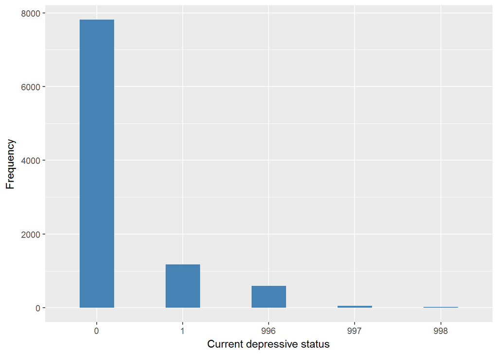

#### 2.1.7.4 Validation

|  | <4->0 | >=4->1 | (-1,-2)->996 | -9->997 | -8->998 |
| --- | --- | --- | --- | --- | --- |
| BeforeH | 7817 | 1175 | 597 | 52 | 25 |
| AfterH | 7817 | 1175 | 597 | 52 | 25 |

# 3 Quality estimation

ELSA used the eight item version of the Center for Epidemiologic Studies Depression Scale (CES-D) to measure depressive symptoms. To determine depressive symptoms, each self-respondent was asked the following questions with response options of ‘yes’ or ‘no’: 1) Much of the time during the past week, I felt depressed; 2) I felt everything I did was an effort; 3) My sleep was restless; 4) I was happy; 5) I felt lonely; 6) I enjoyed life; 7) I felt sad; 8) I could not “get going”. For each respondent, the total number of “yes” responses to questions 1, 2, 3, 5, 7, 8, and the “no” responses to questions 4 and 6 were summed to arrive at a total depressive symptom score ranging from 0 to 8. We classified those who reported four or more depressive symptoms as having significant depressive symptoms, a cut-off that has been found to produce comparable results to the 16-symptom cut-off for the well-validated 20-item CES-D scale. =4 We get the final variable using the sigle items because we didn’t have the final score. Regarding the missing values, we follow this criteria: only one missing item was allowed > score the completed items divided by the number of items answered and multiplied by 8.